# The significance of education on the salary of engineers in Sweden

Mikael Lundqvist

2019-12-15

In my last posts, I analysed the significance of experience for different occupational groups. In this post, I will turn the interest towards education. I will again start with engineers and see if I can expand my analysis to all occupational groups.

First, define libraries and functions.

```r
library (tidyverse)
library (broom)
library (car)
library (splines)
#install_github("ZheyuanLi/SplinesUtils")
library(SplinesUtils)

readfile <- function (file1){
  read_csv (file1, col_types = cols(), locale = readr::locale (encoding = "latin1"), na = c("..", "NA")) %>%
    gather (starts_with("19"), starts_with("20"), key = "year", value = salary) %>%
    drop_na() %>%
    mutate (year_n = parse_number (year))
}
```

The data table is downloaded from Statistics Sweden. It is saved as a comma-delimited file without heading, 000000CY.csv, http://www.statistikdatabasen.scb.se/pxweb/en/ssd/.

The table: Average basic salary, monthly salary and women´s salary as a percentage of men´s salary by sector, occupational group (SSYK 2012), sex and educational level (SUN). Year 2014 - 2018 Monthly salary All sectors

We expect that education is an important factor in salaries. As a null hypothesis, we assume that education is not related to the salary and examine if we can reject this hypothesis with the data from Statistics Sweden.

The column `level of education` is renamed because TukeyHSD doesn’t handle variable names within quotes.

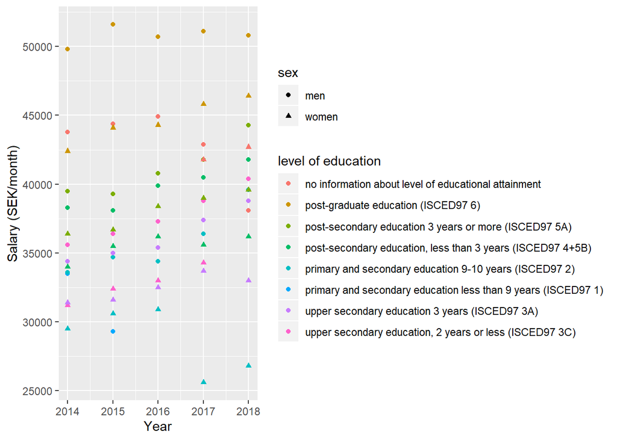

```r
tb <- readfile("000000CY.csv") %>%
  filter(`occuptional  (SSYK 2012)` == "311 Physical and engineering science technicians") %>%
  mutate(edulevel = `level of education`)

tb %>%
  ggplot () +
    geom_point (mapping = aes(x = year_n,y = salary, colour = `level of education`, shape=sex)) +
  labs(
    x = "Year",
    y = "Salary (SEK/month)"
  )
```

```r
model <- lm (log(salary) ~ year_n + sex + edulevel, data = tb)

tb <- bind_cols(tb, as_tibble(exp(predict(model, tb, interval = "confidence"))))
```

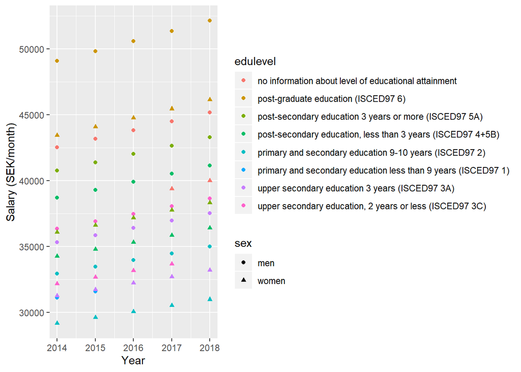

```r
tb %>%
  ggplot () +
    geom_point (mapping = aes(x = year_n,y = fit, colour = edulevel, shape = sex)) +
  labs(
    x = "Year",
    y = "Salary (SEK/month)"
  )
```

```r
summary(model) %>%
  tidy() %>%
  knitr::kable(
  booktabs = TRUE,
  caption = 'Summary from linear model fit')
```

Summary from linear model fit

| term | estimate | std.error | statistic | p.value |
| --- | --- | --- | --- | --- |
| (Intercept) | -19.8506159 | 8.9566566 | -2.216298 | 0.0306078 |
| year_n | 0.0151482 | 0.0044419 | 3.410314 | 0.0011871 |
| sexwomen | -0.1222074 | 0.0125909 | -9.706030 | 0.0000000 |
| edulevelpost-graduate education (ISCED97 6) | 0.1432839 | 0.0251521 | 5.696699 | 0.0000004 |
| edulevelpost-secondary education 3 years or more (ISCED97 5A) | -0.0424599 | 0.0251521 | -1.688127 | 0.0967576 |
| edulevelpost-secondary education, less than 3 years (ISCED97 4+5B) | -0.0939885 | 0.0251521 | -3.736808 | 0.0004279 |
| edulevelprimary and secondary education 9-10 years (ISCED97 2) | -0.2552620 | 0.0251521 | -10.148741 | 0.0000000 |
| edulevelprimary and secondary education less than 9 years (ISCED97 1) | -0.3130631 | 0.0415940 | -7.526633 | 0.0000000 |
| edulevelupper secondary education 3 years (ISCED97 3A) | -0.1857063 | 0.0251521 | -7.383336 | 0.0000000 |
| edulevelupper secondary education, 2 years or less (ISCED97 3C) | -0.1567392 | 0.0257398 | -6.089370 | 0.0000001 |

```r
summary(model)$adj.r.squared
```

```
## [1] 0.889867
```

```r
Anova(model, type = 2) %>%
  tidy() %>%
  knitr::kable(
  booktabs = TRUE,
  caption = 'Anova report from linear model fit')
```

Anova report from linear model fit

| term | sumsq | df | statistic | p.value |
| --- | --- | --- | --- | --- |
| year_n | 0.0297628 | 1 | 11.63024 | 0.0011871 |
| sex | 0.2410840 | 1 | 94.20703 | 0.0000000 |
| edulevel | 1.1181260 | 7 | 62.41768 | 0.0000000 |
| Residuals | 0.1484271 | 58 | NA | NA |

How much do the different levels of education affect the salary? We can calculate the differences between the levels with Tukey’s honest significant difference. All significant level differences are shown in the table below.

```r
tukeytable <- TukeyHSD(aov(log(salary) ~ sex + edulevel, data = tb)) %>%
  tidy() %>%
  mutate(percdiff = (1 / exp(estimate) - 1) * 100)

tukeytable  %>%
  filter(adj.p.value < 0.05) %>%
  arrange(estimate) %>%
  knitr::kable(
  booktabs = TRUE,
  caption = 'Tukey HSD 95 % confidence intervals for the pairwise significant differences')
```

Tukey HSD 95 % confidence intervals for the pairwise significant differences

| term | comparison | estimate | conf.low | conf.high | adj.p.value | percdiff |
| --- | --- | --- | --- | --- | --- | --- |
| edulevel | primary and secondary education less than 9 years (ISCED97 1)-post-graduate education (ISCED97 6) | -0.4749487 | -0.6087086 | -0.3411889 | 0.0000000 | 60.793177 |
| edulevel | primary and secondary education 9-10 years (ISCED97 2)-post-graduate education (ISCED97 6) | -0.3985459 | -0.4757722 | -0.3213196 | 0.0000000 | 48.965699 |
| edulevel | primary and secondary education less than 9 years (ISCED97 1)-no information about level of educational attainment | -0.3399229 | -0.4783774 | -0.2014683 | 0.0000000 | 40.483923 |
| edulevel | upper secondary education 3 years (ISCED97 3A)-post-graduate education (ISCED97 6) | -0.3289902 | -0.4062165 | -0.2517639 | 0.0000000 | 38.956422 |
| edulevel | upper secondary education, 2 years or less (ISCED97 3C)-post-graduate education (ISCED97 6) | -0.3029315 | -0.3822740 | -0.2235891 | 0.0000000 | 35.382178 |
| edulevel | primary and secondary education less than 9 years (ISCED97 1)-post-secondary education 3 years or more (ISCED97 5A) | -0.2892050 | -0.4229648 | -0.1554451 | 0.0000002 | 33.536541 |
| edulevel | primary and secondary education 9-10 years (ISCED97 2)-no information about level of educational attainment | -0.2635200 | -0.3486192 | -0.1784208 | 0.0000000 | 30.150334 |
| edulevel | primary and secondary education less than 9 years (ISCED97 1)-post-secondary education, less than 3 years (ISCED97 4+5B) | -0.2376764 | -0.3714362 | -0.1039165 | 0.0000167 | 26.829865 |
| edulevel | post-secondary education, less than 3 years (ISCED97 4+5B)-post-graduate education (ISCED97 6) | -0.2372724 | -0.3144987 | -0.1600461 | 0.0000000 | 26.778640 |
| edulevel | primary and secondary education 9-10 years (ISCED97 2)-post-secondary education 3 years or more (ISCED97 5A) | -0.2128021 | -0.2900284 | -0.1355758 | 0.0000000 | 23.713981 |
| edulevel | upper secondary education 3 years (ISCED97 3A)-no information about level of educational attainment | -0.1939643 | -0.2790635 | -0.1088651 | 0.0000000 | 21.405296 |
| edulevel | post-secondary education 3 years or more (ISCED97 5A)-post-graduate education (ISCED97 6) | -0.1857438 | -0.2629700 | -0.1085175 | 0.0000000 | 20.411370 |
| edulevel | upper secondary education, 2 years or less (ISCED97 3C)-no information about level of educational attainment | -0.1679057 | -0.2549298 | -0.0808815 | 0.0000028 | 18.282502 |
| edulevel | primary and secondary education 9-10 years (ISCED97 2)-post-secondary education, less than 3 years (ISCED97 4+5B) | -0.1612735 | -0.2384998 | -0.0840472 | 0.0000004 | 17.500629 |
| edulevel | upper secondary education 3 years (ISCED97 3A)-post-secondary education 3 years or more (ISCED97 5A) | -0.1432464 | -0.2204727 | -0.0660201 | 0.0000067 | 15.401413 |
| edulevel | upper secondary education, 2 years or less (ISCED97 3C)-post-secondary education 3 years or more (ISCED97 5A) | -0.1171878 | -0.1965302 | -0.0378453 | 0.0004990 | 12.433052 |
| sex | women-men | -0.1139665 | -0.1407418 | -0.0871912 | 0.0000000 | 12.071456 |
| edulevel | post-secondary education, less than 3 years (ISCED97 4+5B)-no information about level of educational attainment | -0.1022465 | -0.1873457 | -0.0171473 | 0.0083959 | 10.765649 |
| edulevel | upper secondary education 3 years (ISCED97 3A)-post-secondary education, less than 3 years (ISCED97 4+5B) | -0.0917178 | -0.1689441 | -0.0144915 | 0.0095752 | 9.605547 |
| edulevel | upper secondary education, 2 years or less (ISCED97 3C)-primary and secondary education 9-10 years (ISCED97 2) | 0.0956143 | 0.0162719 | 0.1749568 | 0.0081134 | -9.118557 |
| edulevel | post-graduate education (ISCED97 6)-no information about level of educational attainment | 0.1350259 | 0.0499267 | 0.2201251 | 0.0001485 | -12.630669 |
| edulevel | upper secondary education 3 years (ISCED97 3A)-primary and secondary education less than 9 years (ISCED97 1) | 0.1459586 | 0.0121987 | 0.2797184 | 0.0231123 | -13.580648 |
| edulevel | upper secondary education, 2 years or less (ISCED97 3C)-primary and secondary education less than 9 years (ISCED97 1) | 0.1720172 | 0.0370245 | 0.3070099 | 0.0041316 | -15.803531 |

We can conclude from the summary table that there is a positive correlation between longer education and higher salaries.

From the table of Tukey’s honest significant difference, we can see the difference in salaries between the different education lengths. Note that the estimates are negative due to the log transformation, the untransformed differences are in the column percdiff.

Can we approximate how much the salaries increase by one year of education by assigning a numeric value to the factors in the table?

As a first approach, I will use the data in the following table.

I will use a B-spline function to approximate the increase in salaries over age. The rows for “no information about the level of educational attainment” is removed from the table from Statistics Sweden.

```r
numedulevel <- read.csv("edulevel.csv")

numedulevel %>%
  knitr::kable(
  booktabs = TRUE,
  caption = 'Initial approach, length of education')
```

Initial approach, length of education

| level.of.education | eduyears |
| --- | --- |
| primary and secondary education 9-10 years (ISCED97 2) | 9 |
| upper secondary education, 2 years or less (ISCED97 3C) | 11 |
| upper secondary education 3 years (ISCED97 3A) | 12 |
| post-secondary education, less than 3 years (ISCED97 4+5B) | 14 |
| post-secondary education 3 years or more (ISCED97 5A) | 15 |
| post-graduate education (ISCED97 6) | 19 |
| no information about level of educational attainment | NA |

```r
tbnum <- tb %>%
    right_join(numedulevel, by = c("level of education" = "level.of.education")) %>%
  filter(!is.na(eduyears))
modelcont <- lm(log(salary) ~ bs(eduyears, knots = c(14)) + year_n + sex, data = tbnum)

tbnum <- bind_cols(tbnum, as_tibble(exp(predict(modelcont, tbnum, interval = "confidence"))))
```

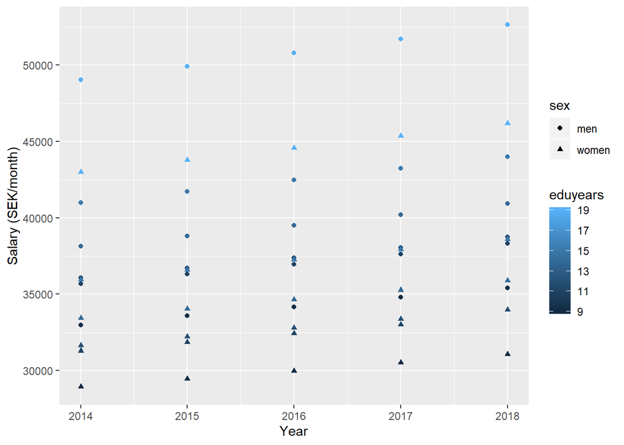

```r
tbnum %>%
  ggplot () +
    geom_point (mapping = aes(x = year_n,y = fit1, colour = eduyears, shape = sex)) +
  labs(
    x = "Year",
    y = "Salary (SEK/month)"
  )
```

```r
summary(modelcont) %>%
  tidy() %>%
  knitr::kable(
  booktabs = TRUE,
  caption = 'Summary from linear model fit')
```

Summary from linear model fit

| term | estimate | std.error | statistic | p.value |
| --- | --- | --- | --- | --- |
| (Intercept) | -25.3710717 | 8.4309679 | -3.0092715 | 0.0040318 |
| bs(eduyears, knots = c(14))1 | 0.1263429 | 0.0445394 | 2.8366580 | 0.0064829 |
| bs(eduyears, knots = c(14))2 | -0.0244997 | 0.0879372 | -0.2786049 | 0.7816530 |
| bs(eduyears, knots = c(14))3 | 0.5018087 | 0.1057574 | 4.7449063 | 0.0000167 |
| bs(eduyears, knots = c(14))4 | 0.3964127 | 0.0200863 | 19.7354477 | 0.0000000 |
| year_n | 0.0177631 | 0.0041820 | 4.2475601 | 0.0000896 |
| sexwomen | -0.1311370 | 0.0117195 | -11.1896610 | 0.0000000 |

```r
summary(modelcont)$adj.r.squared
```

```
## [1] 0.9133582
```